# **Proyecto Parcial 3: Redes neruonales**

**Objetivo:** Este proyecto tiene como objetivo generar un modelo de clasificación utilizando redes neuronales que pueda identificar números del 0 al 9 en tiempo real, utilizando como base de datos para entrenar dicho modelo un banco de imágenes creada por grupos de Inteligencia Artificial.

```python
# Basic imports
import numpy as np
import matplotlib.pyplot as plt
import tensorflow as tf
import cv2
```

Comenzaremos importando las imagenes. En este caso la base de datos está guardada en el ambiente local, y para acceder a ella haremos uso de la librería *ImageDataGenerator* de Keras.

El tamaño de las imagenes es de 28x28px, en forma cuadrada y RGB, es decir, a color. La única diferencia que esto implica con talleres anteriores es que ahora hay que inidicar 'rgb' en la especificación 'color_mode', y un detalle más al definir el modelo CNN que veremos después.

```python
# Import dataset
#from tensorflow.keras.datasets import mnist
#(train_images, train_labels), (test_images, test_labels) = mnist.load_data()
from tensorflow.keras.preprocessing.image import ImageDataGenerator

#Código hecho con ayuda de ChatGPT
# Rutas a las carpetas
train_dir = 'Numbers/Train'
test_dir = 'Numbers/Test'

# Parámetros de imagen
img_height, img_width = 28, 28  # Ajusta según el tamaño real de tus imágenes
batch_size = 32

# Generador para el conjunto de entrenamiento
train_datagen = ImageDataGenerator(rescale=1./255)

train_generator = train_datagen.flow_from_directory(
    train_dir,
    target_size=(img_height, img_width),
    color_mode='rgb',  # o 'rgb' si son imágenes a color
    batch_size=batch_size,
    class_mode='categorical',  # para clasificación multiclase
    shuffle=True
)

# Generador para el conjunto de prueba
test_datagen = ImageDataGenerator(rescale=1./255)

test_generator = test_datagen.flow_from_directory(
    test_dir,
    target_size=(img_height, img_width),
    color_mode='rgb',
    batch_size=batch_size,
    class_mode='categorical',
    shuffle=False
)
```

```
Found 5206 images belonging to 10 classes.
Found 1397 images belonging to 10 classes.
```

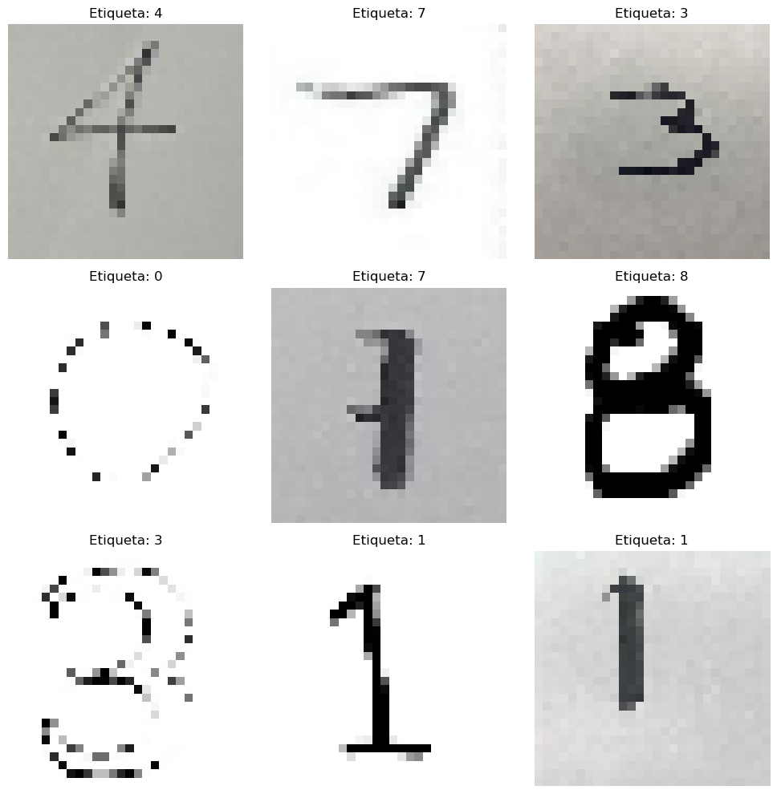

```python
# Obtener un batch de imágenes y etiquetas
images, labels = next(train_generator)

# Mostrar las primeras 9 imágenes del batch
plt.figure(figsize=(10, 10))
for i in range(9):
    plt.subplot(3, 3, i + 1)
    # Elimina el canal si es escala de grises
    image = images[i].squeeze() if images[i].shape[-1] == 1 else images[i]
    plt.imshow(image, cmap='gray' if image.ndim == 2 else None)
    plt.title(f"Etiqueta: {np.argmax(labels[i])}")
    plt.axis('off')
plt.tight_layout()
plt.show()
```

Como se puede observar, las imagenes se ven muy diferentes a las utilizadas en el taller anterior. Primeramente estas tienen letras de color negro, y el fondo, en lugar de ser color negro, conserva el color original de la foto, en la muestra estos son blanco y una variedad de grises. Además de esto, los números también están escritos de formas diferentes a los de el taller previo, esto podría ayudar a aportar más variedad al modelo o podría perjudicarlo al oferecer demasiados patrones que identificar.

De cualquier forma ahora podemos utilizar las imagenes para entrenar nuestro modelo CNN, pero antes de definir el modelo definitivo, vamos a probar varias iteraciones de modelos CNN para buscar los parámetros del más óptimo. Para esto el primer paso es dividir las imagenes dentro del directorio de Train en 'Train' y 'Test' para realizar las pruebas con un modelo base al que después iremos realizando modificaciones.

```python
from tensorflow.keras.preprocessing.image import ImageDataGenerator

# Parámetros de imagen
img_height, img_width = 28, 28
batch_size = 32

# Generador con validación dividida
datagen = ImageDataGenerator(
    rescale=1./255,
    validation_split=0.2  # 20% para validación
)

# Generador para entrenamiento
train_generator_train = datagen.flow_from_directory(
    'Numbers/Train',
    target_size=(img_height, img_width),
    color_mode='rgb',
    batch_size=batch_size,
    class_mode='categorical',
    subset='training',
    shuffle=True
)

# Generador para validación
val_generator = datagen.flow_from_directory(
    'Numbers/Train',
    target_size=(img_height, img_width),
    color_mode='rgb',
    batch_size=batch_size,
    class_mode='categorical',
    subset='validation',
    shuffle=False
)
```

```
Found 4168 images belonging to 10 classes.
Found 1038 images belonging to 10 classes.
```

### **Modelo Base**

```python
from tensorflow.keras import layers
from tensorflow.keras import models

# Initialize the model
model = models.Sequential()

# First hidden layer (convolution layer)
model.add(layers.Conv2D(32, (3, 3), padding='same', activation='relu', input_shape=(28, 28, 3)))
model.add(layers.MaxPooling2D((2, 2)))

# Second hidden layer (convolution layer)
model.add(layers.Conv2D(64, (3, 3), padding='same', activation='relu'))
model.add(layers.MaxPooling2D((2, 2)))

# Third hidden layer (convolution layer)
model.add(layers.Conv2D(128, (3, 3), padding='same', activation='relu'))

# Convert feature maps into individual units
model.add(layers.Flatten())

# Add fully connected layer
model.add(layers.Dense(64, activation='relu'))

# Add output layer
model.add(layers.Dense(10, activation='softmax'))

# Compile the model
model.compile(optimizer='adam',
              loss='categorical_crossentropy',
              metrics=['accuracy'])

# Display the architecture of the model
model.summary()
```

```
Model: "sequential_1"
```

```
┏━━━━━━━━━━━━━━━━━━━━━━━━━━━━━━━━━━━━━━┳━━━━━━━━━━━━━━━━━━━━━━━━━━━━━┳━━━━━━━━━━━━━━━━━┓
┃ Layer (type)                         ┃ Output Shape                ┃         Param # ┃
┡━━━━━━━━━━━━━━━━━━━━━━━━━━━━━━━━━━━━━━╇━━━━━━━━━━━━━━━━━━━━━━━━━━━━━╇━━━━━━━━━━━━━━━━━┩
│ conv2d_3 (Conv2D)                    │ (None, 28, 28, 32)          │             896 │
├──────────────────────────────────────┼─────────────────────────────┼─────────────────┤
│ max_pooling2d_2 (MaxPooling2D)       │ (None, 14, 14, 32)          │               0 │
├──────────────────────────────────────┼─────────────────────────────┼─────────────────┤
│ conv2d_4 (Conv2D)                    │ (None, 14, 14, 64)          │          18,496 │
├──────────────────────────────────────┼─────────────────────────────┼─────────────────┤
│ max_pooling2d_3 (MaxPooling2D)       │ (None, 7, 7, 64)            │               0 │
├──────────────────────────────────────┼─────────────────────────────┼─────────────────┤
│ conv2d_5 (Conv2D)                    │ (None, 7, 7, 128)           │          73,856 │
├──────────────────────────────────────┼─────────────────────────────┼─────────────────┤
│ flatten_1 (Flatten)                  │ (None, 6272)                │               0 │
├──────────────────────────────────────┼─────────────────────────────┼─────────────────┤
│ dense_2 (Dense)                      │ (None, 64)                  │         401,472 │
├──────────────────────────────────────┼─────────────────────────────┼─────────────────┤
│ dense_3 (Dense)                      │ (None, 10)                  │             650 │
└──────────────────────────────────────┴─────────────────────────────┴─────────────────┘
```

```
 Total params: 495,370 (1.89 MB)
```

```
 Trainable params: 495,370 (1.89 MB)
```

```
 Non-trainable params: 0 (0.00 B)
```

Este modelo base tiene tres capas de convolución, dos capas de MaxPooling, una capa flatten para convertir los feature maps en unidades individuales, una capa dense totalmente conectada y una última capa de output.

Ahora procedamos a entrenar el modelo y ver sus resultados.

```python
# Create early stoppingg callback
from tensorflow.keras.callbacks import EarlyStopping
early_stop = EarlyStopping(monitor='val_accuracy', patience=5, restore_best_weights=True)

# Train the model
history = model.fit(
    train_generator_train,
    epochs=30,
    validation_data=val_generator, callbacks=[early_stop])

#history = model.fit(train_images, train_labels, epochs=30, batch_size=64, validation_split=0.3, callbacks=[early_stop])
```

```
131/131 ━━━━━━━━━━━━━━━━━━━━ 149s 1s/step - accuracy: 0.2324 - loss: 2.1011 - val_accuracy: 0.6069 - val_loss: 1.3959
131/131 ━━━━━━━━━━━━━━━━━━━━ 59s 454ms/step - accuracy: 0.6505 - loss: 1.0900 - val_accuracy: 0.7380 - val_loss: 0.9859
131/131 ━━━━━━━━━━━━━━━━━━━━ 61s 465ms/step - accuracy: 0.7722 - loss: 0.6885 - val_accuracy: 0.7967 - val_loss: 0.8237
131/131 ━━━━━━━━━━━━━━━━━━━━ 60s 461ms/step - accuracy: 0.8407 - loss: 0.4999 - val_accuracy: 0.8198 - val_loss: 0.8340
131/131 ━━━━━━━━━━━━━━━━━━━━ 58s 442ms/step - accuracy: 0.8680 - loss: 0.4096 - val_accuracy: 0.8141 - val_loss: 0.8726
131/131 ━━━━━━━━━━━━━━━━━━━━ 60s 463ms/step - accuracy: 0.8980 - loss: 0.3255 - val_accuracy: 0.8189 - val_loss: 0.8526
131/131 ━━━━━━━━━━━━━━━━━━━━ 60s 457ms/step - accuracy: 0.9119 - loss: 0.2850 - val_accuracy: 0.8227 - val_loss: 0.8894
131/131 ━━━━━━━━━━━━━━━━━━━━ 61s 465ms/step - accuracy: 0.9301 - loss: 0.2285 - val_accuracy: 0.8324 - val_loss: 1.0279
131/131 ━━━━━━━━━━━━━━━━━━━━ 60s 460ms/step - accuracy: 0.9383 - loss: 0.1885 - val_accuracy: 0.8141 - val_loss: 1.1012
131/131 ━━━━━━━━━━━━━━━━━━━━ 59s 454ms/step - accuracy: 0.9389 - loss: 0.1743 - val_accuracy: 0.8343 - val_loss: 1.0123
131/131 ━━━━━━━━━━━━━━━━━━━━ 58s 443ms/step - accuracy: 0.9576 - loss: 0.1449 - val_accuracy: 0.8160 - val_loss: 1.1796
131/131 ━━━━━━━━━━━━━━━━━━━━ 58s 442ms/step - accuracy: 0.9484 - loss: 0.1681 - val_accuracy: 0.8343 - val_loss: 1.1371
131/131 ━━━━━━━━━━━━━━━━━━━━ 60s 457ms/step - accuracy: 0.9715 - loss: 0.1007 - val_accuracy: 0.8382 - val_loss: 1.3969
131/131 ━━━━━━━━━━━━━━━━━━━━ 58s 440ms/step - accuracy: 0.9739 - loss: 0.0790 - val_accuracy: 0.8449 - val_loss: 1.2666
131/131 ━━━━━━━━━━━━━━━━━━━━ 57s 432ms/step - accuracy: 0.9676 - loss: 0.0998 - val_accuracy: 0.8256 - val_loss: 1.3310
131/131 ━━━━━━━━━━━━━━━━━━━━ 56s 426ms/step - accuracy: 0.9799 - loss: 0.0732 - val_accuracy: 0.8382 - val_loss: 1.4813
131/131 ━━━━━━━━━━━━━━━━━━━━ 55s 420ms/step - accuracy: 0.9844 - loss: 0.0498 - val_accuracy: 0.8410 - val_loss: 1.4892
131/131 ━━━━━━━━━━━━━━━━━━━━ 58s 444ms/step - accuracy: 0.9904 - loss: 0.0348 - val_accuracy: 0.8497 - val_loss: 1.4008
131/131 ━━━━━━━━━━━━━━━━━━━━ 57s 436ms/step - accuracy: 0.9915 - loss: 0.0344 - val_accuracy: 0.8459 - val_loss: 1.5816
131/131 ━━━━━━━━━━━━━━━━━━━━ 60s 454ms/step - accuracy: 0.9934 - loss: 0.0364 - val_accuracy: 0.8410 - val_loss: 1.5954
131/131 ━━━━━━━━━━━━━━━━━━━━ 56s 430ms/step - accuracy: 0.9839 - loss: 0.0650 - val_accuracy: 0.8439 - val_loss: 1.6887
131/131 ━━━━━━━━━━━━━━━━━━━━ 63s 483ms/step - accuracy: 0.9806 - loss: 0.0542 - val_accuracy: 0.8333 - val_loss: 1.7327
131/131 ━━━━━━━━━━━━━━━━━━━━ 61s 462ms/step - accuracy: 0.9899 - loss: 0.0447 - val_accuracy: 0.8439 - val_loss: 1.8200
```

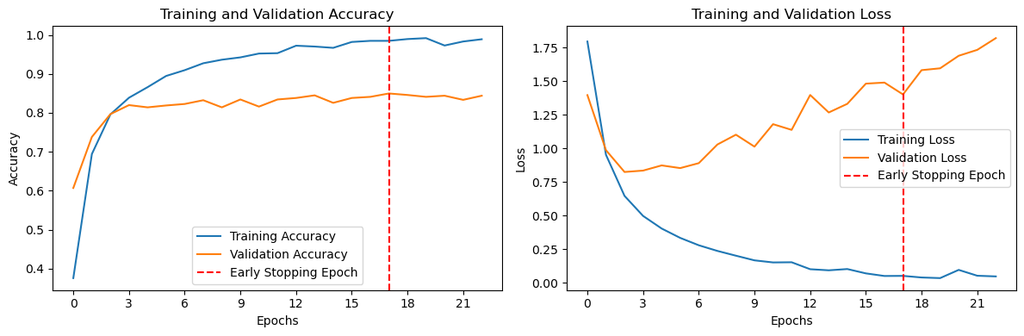

```python
# Plotting the training and validation accuracy
from matplotlib.ticker import MaxNLocator

stopped_epoch = early_stop.stopped_epoch
best_epoch = stopped_epoch - early_stop.patience

plt.figure(figsize=(12, 4))

plt.subplot(1, 2, 1)
plt.plot(history.history['accuracy'], label='Training Accuracy')
plt.plot(history.history['val_accuracy'], label='Validation Accuracy')
plt.axvline(x=best_epoch, color='r', linestyle='--', label='Early Stopping Epoch')
plt.title('Training and Validation Accuracy')
plt.xlabel('Epochs')
plt.ylabel('Accuracy')
plt.gca().xaxis.set_major_locator(MaxNLocator(integer=True))  # Ensure integer values on x-axis
plt.legend()

plt.subplot(1, 2, 2)
plt.plot(history.history['loss'], label='Training Loss')
plt.plot(history.history['val_loss'], label='Validation Loss')
plt.axvline(x=best_epoch, color='r', linestyle='--', label='Early Stopping Epoch')
plt.title('Training and Validation Loss')
plt.xlabel('Epochs')
plt.ylabel('Loss')
plt.gca().xaxis.set_major_locator(MaxNLocator(integer=True))  # Ensure integer values on x-axis
plt.legend()

plt.tight_layout()
plt.show()
```

```python
# Evaluación
test_loss, test_acc = model.evaluate(test_generator)
print(f"Precisión Modelo Base: {test_acc:.2f}")
```

```
44/44 ━━━━━━━━━━━━━━━━━━━━ 40s 918ms/step - accuracy: 0.8599 - loss: 0.7787
Precisión Modelo Base: 0.85
```

El modelo es funcional y puede ser utilizado para identificar números del 0 al 9 con bastante confianza, pero podría ser mejor, y esto lo probaremos haciendo variaciones a los hiperparámetros y construcción del modelo base.

### **Variación 1**

Para este modelo haremos un cambio relativamente pequeño: agregaremos más capas convolucionales de forma que se puedan capturar patrones más complejos en nuestro dataset. Es decir, agregaremos una capa oculta más después de la segunda, quedando así, en total, con 4 capas. Además se agrega un Dropout leve para evitar overfitting.

```
131/131 ━━━━━━━━━━━━━━━━━━━━ 64s 465ms/step - accuracy: 0.2506 - loss: 2.1234 - val_accuracy: 0.5819 - val_loss: 1.9774
131/131 ━━━━━━━━━━━━━━━━━━━━ 63s 478ms/step - accuracy: 0.6511 - loss: 1.0931 - val_accuracy: 0.7168 - val_loss: 1.2660
131/131 ━━━━━━━━━━━━━━━━━━━━ 63s 484ms/step - accuracy: 0.7544 - loss: 0.7483 - val_accuracy: 0.7813 - val_loss: 0.8302
131/131 ━━━━━━━━━━━━━━━━━━━━ 64s 492ms/step - accuracy: 0.8067 - loss: 0.5894 - val_accuracy: 0.8102 - val_loss: 0.7811
131/131 ━━━━━━━━━━━━━━━━━━━━ 63s 481ms/step - accuracy: 0.8512 - loss: 0.4518 - val_accuracy: 0.8121 - val_loss: 0.7882
131/131 ━━━━━━━━━━━━━━━━━━━━ 63s 485ms/step - accuracy: 0.8643 - loss: 0.4137 - val_accuracy: 0.8208 - val_loss: 0.8720
131/131 ━━━━━━━━━━━━━━━━━━━━ 80s 467ms/step - accuracy: 0.8757 - loss: 0.3793 - val_accuracy: 0.7909 - val_loss: 1.0426
131/131 ━━━━━━━━━━━━━━━━━━━━ 57s 434ms/step - accuracy: 0.9053 - loss: 0.2949 - val_accuracy: 0.8083 - val_loss: 1.0042
131/131 ━━━━━━━━━━━━━━━━━━━━ 57s 438ms/step - accuracy: 0.9148 - loss: 0.2712 - val_accuracy: 0.8372 - val_loss: 0.9268
131/131 ━━━━━━━━━━━━━━━━━━━━ 57s 432ms/step - accuracy: 0.9209 - loss: 0.2329 - val_accuracy: 0.8372 - val_loss: 0.9143
131/131 ━━━━━━━━━━━━━━━━━━━━ 57s 432ms/step - accuracy: 0.9416 - loss: 0.1766 - val_accuracy: 0.8227 - val_loss: 0.9666
131/131 ━━━━━━━━━━━━━━━━━━━━ 58s 439ms/step - accuracy: 0.9497 - loss: 0.1650 - val_accuracy: 0.8092 - val_loss: 1.0649
131/131 ━━━━━━━━━━━━━━━━━━━━ 57s 440ms/step - accuracy: 0.9460 - loss: 0.1663 - val_accuracy: 0.8401 - val_loss: 1.1375
131/131 ━━━━━━━━━━━━━━━━━━━━ 57s 433ms/step - accuracy: 0.9553 - loss: 0.1434 - val_accuracy: 0.8353 - val_loss: 1.0807
131/131 ━━━━━━━━━━━━━━━━━━━━ 57s 439ms/step - accuracy: 0.9538 - loss: 0.1288 - val_accuracy: 0.8266 - val_loss: 1.1707
131/131 ━━━━━━━━━━━━━━━━━━━━ 57s 436ms/step - accuracy: 0.9610 - loss: 0.1096 - val_accuracy: 0.8266 - val_loss: 1.3018
131/131 ━━━━━━━━━━━━━━━━━━━━ 56s 428ms/step - accuracy: 0.9510 - loss: 0.1522 - val_accuracy: 0.8574 - val_loss: 1.1910
131/131 ━━━━━━━━━━━━━━━━━━━━ 56s 431ms/step - accuracy: 0.9764 - loss: 0.0792 - val_accuracy: 0.8478 - val_loss: 1.1533
131/131 ━━━━━━━━━━━━━━━━━━━━ 57s 437ms/step - accuracy: 0.9726 - loss: 0.0958 - val_accuracy: 0.8555 - val_loss: 1.3594
131/131 ━━━━━━━━━━━━━━━━━━━━ 56s 426ms/step - accuracy: 0.9683 - loss: 0.0853 - val_accuracy: 0.8372 - val_loss: 1.2998
131/131 ━━━━━━━━━━━━━━━━━━━━ 56s 431ms/step - accuracy: 0.9731 - loss: 0.0765 - val_accuracy: 0.8304 - val_loss: 1.2276
131/131 ━━━━━━━━━━━━━━━━━━━━ 58s 443ms/step - accuracy: 0.9654 - loss: 0.1151 - val_accuracy: 0.8449 - val_loss: 1.3636
```

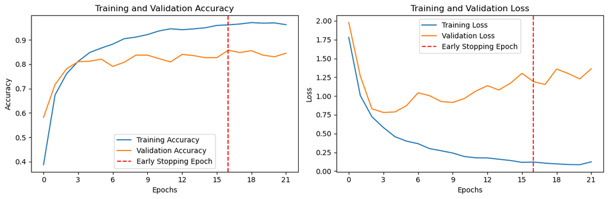

```python
# Initialize the model
model1 = models.Sequential()

# First hidden layer (convolution layer)
model1.add(layers.Conv2D(32, (3, 3), padding='same', input_shape=(28, 28, 3)))
model1.add(layers.BatchNormalization())
model1.add(layers.Activation('relu'))
model1.add(layers.MaxPooling2D((2, 2)))
model1.add(layers.Dropout(0.1))

# Second hidden layer (convolution layer)
model1.add(layers.Conv2D(64, (3, 3), padding='same', activation='relu'))
model1.add(layers.MaxPooling2D((2, 2)))
model1.add(layers.Dropout(0.1))

#Código con ayuda de ChatGPT
# Tercera hidden layer (convolution layer)
model1.add(layers.Conv2D(64, (3, 3), padding='same', activation='relu'))

# Cuarta hidden layer (convolution layer)
model1.add(layers.Conv2D(128, (3, 3), padding='same', activation='relu'))

# Convert feature maps into individual units
model1.add(layers.Flatten())

# Add fully connected layer
model1.add(layers.Dense(128, activation='relu'))
model1.add(layers.Dropout(0.25))

# Add output layer
model1.add(layers.Dense(10, activation='softmax')) # 10 classes for digits 0-9

# Compile the model
model1.compile(optimizer='adam',
              loss='categorical_crossentropy',
              metrics=['accuracy'])

# Train the model
history1 = model1.fit(train_generator_train,
    epochs=30,
    validation_data=val_generator, callbacks=[early_stop])

#history2 = model2.fit(train_images, train_labels, epochs=30, batch_size=64, validation_split=0.3, callbacks=[early_stop])

# Plotting the training and validation accuracy
stopped_epoch = early_stop.stopped_epoch
best_epoch = stopped_epoch - early_stop.patience

plt.figure(figsize=(12, 4))

plt.subplot(1, 2, 1)
plt.plot(history1.history['accuracy'], label='Training Accuracy')
plt.plot(history1.history['val_accuracy'], label='Validation Accuracy')
plt.axvline(x=best_epoch, color='r', linestyle='--', label='Early Stopping Epoch')
plt.title('Training and Validation Accuracy')
plt.xlabel('Epochs')
plt.ylabel('Accuracy')
plt.gca().xaxis.set_major_locator(MaxNLocator(integer=True))  # Ensure integer values on x-axis
plt.legend()

plt.subplot(1, 2, 2)
plt.plot(history1.history['loss'], label='Training Loss')
plt.plot(history1.history['val_loss'], label='Validation Loss')
plt.axvline(x=best_epoch, color='r', linestyle='--', label='Early Stopping Epoch')
plt.title('Training and Validation Loss')
plt.xlabel('Epochs')
plt.ylabel('Loss')
plt.gca().xaxis.set_major_locator(MaxNLocator(integer=True))  # Ensure integer values on x-axis
plt.legend()

plt.tight_layout()
plt.show()
```

Las gráficas nos muestran que el modelo tuvo su mejor momento alrededor de la época 16, donde podemos observar que el accuracy de Train estuvo alrededor de 0.95, y el accuracy de Test estuvo alrededor de 0.84, esta diferencia nos dice que el modelo tiene un ligero sobreajuste, pero lo evaluaremos después con el dataset de 'Train' para darnos una idea de si es mejor o peor que el modelo base, comparando sus valores de accuracy entre ellos y entre las variaciones siguientes.

### **Variación 2**

Para esta versión agregaremos Dropout en más lugares, y aumentaremos de 0.25 a 0.5, y de 0.1 a 0.3 a fin de minimizar tanto como sea posible el overfitting.

```
131/131 ━━━━━━━━━━━━━━━━━━━━ 65s 469ms/step - accuracy: 0.1148 - loss: 2.3318 - val_accuracy: 0.1522 - val_loss: 2.2798
131/131 ━━━━━━━━━━━━━━━━━━━━ 65s 500ms/step - accuracy: 0.1359 - loss: 2.2363 - val_accuracy: 0.2274 - val_loss: 2.2531
131/131 ━━━━━━━━━━━━━━━━━━━━ 63s 479ms/step - accuracy: 0.1473 - loss: 2.1687 - val_accuracy: 0.3141 - val_loss: 2.1023
131/131 ━━━━━━━━━━━━━━━━━━━━ 59s 451ms/step - accuracy: 0.2231 - loss: 1.9980 - val_accuracy: 0.4817 - val_loss: 1.7414
131/131 ━━━━━━━━━━━━━━━━━━━━ 60s 456ms/step - accuracy: 0.2719 - loss: 1.8346 - val_accuracy: 0.5202 - val_loss: 1.5936
131/131 ━━━━━━━━━━━━━━━━━━━━ 59s 447ms/step - accuracy: 0.3460 - loss: 1.6836 - val_accuracy: 0.6387 - val_loss: 1.4815
131/131 ━━━━━━━━━━━━━━━━━━━━ 62s 479ms/step - accuracy: 0.4020 - loss: 1.5728 - val_accuracy: 0.6628 - val_loss: 1.2481
131/131 ━━━━━━━━━━━━━━━━━━━━ 62s 475ms/step - accuracy: 0.4814 - loss: 1.3791 - val_accuracy: 0.6898 - val_loss: 1.2377
131/131 ━━━━━━━━━━━━━━━━━━━━ 60s 457ms/step - accuracy: 0.5150 - loss: 1.2788 - val_accuracy: 0.7697 - val_loss: 0.9682
131/131 ━━━━━━━━━━━━━━━━━━━━ 62s 475ms/step - accuracy: 0.5711 - loss: 1.1754 - val_accuracy: 0.7958 - val_loss: 0.9372
131/131 ━━━━━━━━━━━━━━━━━━━━ 60s 455ms/step - accuracy: 0.6243 - loss: 1.0023 - val_accuracy: 0.7052 - val_loss: 1.1073
131/131 ━━━━━━━━━━━━━━━━━━━━ 59s 449ms/step - accuracy: 0.6354 - loss: 1.0171 - val_accuracy: 0.7775 - val_loss: 0.8857
131/131 ━━━━━━━━━━━━━━━━━━━━ 60s 455ms/step - accuracy: 0.6884 - loss: 0.8785 - val_accuracy: 0.7601 - val_loss: 0.9432
131/131 ━━━━━━━━━━━━━━━━━━━━ 60s 456ms/step - accuracy: 0.6851 - loss: 0.8479 - val_accuracy: 0.7601 - val_loss: 0.9332
131/131 ━━━━━━━━━━━━━━━━━━━━ 60s 458ms/step - accuracy: 0.7282 - loss: 0.7432 - val_accuracy: 0.7996 - val_loss: 0.9009
131/131 ━━━━━━━━━━━━━━━━━━━━ 60s 456ms/step - accuracy: 0.7273 - loss: 0.7742 - val_accuracy: 0.7736 - val_loss: 0.9115
131/131 ━━━━━━━━━━━━━━━━━━━━ 57s 439ms/step - accuracy: 0.7437 - loss: 0.7166 - val_accuracy: 0.8073 - val_loss: 0.8599
131/131 ━━━━━━━━━━━━━━━━━━━━ 62s 470ms/step - accuracy: 0.7528 - loss: 0.6874 - val_accuracy: 0.8362 - val_loss: 0.8411
131/131 ━━━━━━━━━━━━━━━━━━━━ 61s 471ms/step - accuracy: 0.7648 - loss: 0.6778 - val_accuracy: 0.8198 - val_loss: 0.8561
131/131 ━━━━━━━━━━━━━━━━━━━━ 61s 468ms/step - accuracy: 0.7885 - loss: 0.6175 - val_accuracy: 0.7620 - val_loss: 1.0052
131/131 ━━━━━━━━━━━━━━━━━━━━ 61s 466ms/step - accuracy: 0.7875 - loss: 0.6016 - val_accuracy: 0.8285 - val_loss: 0.9523
131/131 ━━━━━━━━━━━━━━━━━━━━ 60s 462ms/step - accuracy: 0.7906 - loss: 0.5769 - val_accuracy: 0.8439 - val_loss: 0.8038
131/131 ━━━━━━━━━━━━━━━━━━━━ 59s 448ms/step - accuracy: 0.7988 - loss: 0.5579 - val_accuracy: 0.8054 - val_loss: 0.9442
131/131 ━━━━━━━━━━━━━━━━━━━━ 58s 442ms/step - accuracy: 0.8117 - loss: 0.5322 - val_accuracy: 0.8218 - val_loss: 0.8094
131/131 ━━━━━━━━━━━━━━━━━━━━ 61s 467ms/step - accuracy: 0.8100 - loss: 0.5243 - val_accuracy: 0.8285 - val_loss: 0.8572
131/131 ━━━━━━━━━━━━━━━━━━━━ 60s 460ms/step - accuracy: 0.8351 - loss: 0.4984 - val_accuracy: 0.8391 - val_loss: 0.8522
131/131 ━━━━━━━━━━━━━━━━━━━━ 58s 446ms/step - accuracy: 0.8370 - loss: 0.4708 - val_accuracy: 0.8430 - val_loss: 0.9200
```

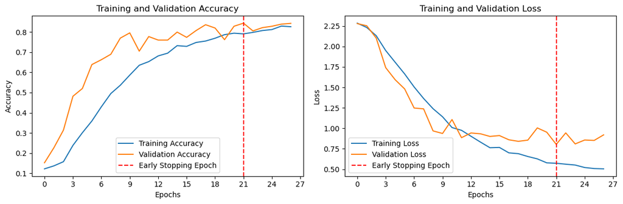

```python
# Initialize the model
model2 = models.Sequential()

# First hidden layer (convolution layer)
model2.add(layers.Conv2D(32, (3, 3), padding='same', input_shape=(28, 28, 3)))
model2.add(layers.BatchNormalization())
model2.add(layers.Activation('relu'))
model2.add(layers.MaxPooling2D((2, 2)))
model2.add(layers.Dropout(0.3))

# Second hidden layer (convolution layer)
model2.add(layers.Conv2D(64, (3, 3), padding='same', activation='relu'))
model2.add(layers.MaxPooling2D((2, 2)))
model2.add(layers.Dropout(0.3))

# Tercera hidden layer (convolution layer)
model2.add(layers.Conv2D(128, (3, 3), padding='same', activation='relu'))

# Convert feature maps into individual units
model2.add(layers.Flatten())

# Add fully connected layer
model2.add(layers.Dense(64, activation='relu'))
model2.add(layers.Dropout(0.5))

# Add output layer
model2.add(layers.Dense(10, activation='softmax')) # 10 classes for digits 0-9

# Compile the model
model2.compile(optimizer='adam',
              loss='categorical_crossentropy',
              metrics=['accuracy'])

# Train the model
history2 = model2.fit(train_generator_train,
    epochs=30,
    validation_data=val_generator, callbacks=[early_stop])

#history2 = model2.fit(train_images, train_labels, epochs=30, batch_size=64, validation_split=0.3, callbacks=[early_stop])

# Plotting the training and validation accuracy
stopped_epoch = early_stop.stopped_epoch
best_epoch = stopped_epoch - early_stop.patience

plt.figure(figsize=(12, 4))

plt.subplot(1, 2, 1)
plt.plot(history2.history['accuracy'], label='Training Accuracy')
plt.plot(history2.history['val_accuracy'], label='Validation Accuracy')
plt.axvline(x=best_epoch, color='r', linestyle='--', label='Early Stopping Epoch')
plt.title('Training and Validation Accuracy')
plt.xlabel('Epochs')
plt.ylabel('Accuracy')
plt.gca().xaxis.set_major_locator(MaxNLocator(integer=True))  # Ensure integer values on x-axis
plt.legend()

plt.subplot(1, 2, 2)
plt.plot(history2.history['loss'], label='Training Loss')
plt.plot(history2.history['val_loss'], label='Validation Loss')
plt.axvline(x=best_epoch, color='r', linestyle='--', label='Early Stopping Epoch')
plt.title('Training and Validation Loss')
plt.xlabel('Epochs')
plt.ylabel('Loss')
plt.gca().xaxis.set_major_locator(MaxNLocator(integer=True))  # Ensure integer values on x-axis
plt.legend()

plt.tight_layout()
plt.show()
```

### **Variación 3**

```
131/131 ━━━━━━━━━━━━━━━━━━━━ 64s 480ms/step - accuracy: 0.1351 - loss: 2.2863 - val_accuracy: 0.3574 - val_loss: 1.8820
131/131 ━━━━━━━━━━━━━━━━━━━━ 61s 462ms/step - accuracy: 0.4784 - loss: 1.5409 - val_accuracy: 0.7013 - val_loss: 1.1283
131/131 ━━━━━━━━━━━━━━━━━━━━ 61s 465ms/step - accuracy: 0.7112 - loss: 0.8787 - val_accuracy: 0.7505 - val_loss: 1.0050
131/131 ━━━━━━━━━━━━━━━━━━━━ 59s 453ms/step - accuracy: 0.7799 - loss: 0.7114 - val_accuracy: 0.7977 - val_loss: 0.9152
131/131 ━━━━━━━━━━━━━━━━━━━━ 62s 476ms/step - accuracy: 0.8356 - loss: 0.4947 - val_accuracy: 0.8237 - val_loss: 0.8137
131/131 ━━━━━━━━━━━━━━━━━━━━ 62s 470ms/step - accuracy: 0.8641 - loss: 0.4157 - val_accuracy: 0.8401 - val_loss: 0.8543
131/131 ━━━━━━━━━━━━━━━━━━━━ 61s 464ms/step - accuracy: 0.8922 - loss: 0.3211 - val_accuracy: 0.8237 - val_loss: 0.8713
131/131 ━━━━━━━━━━━━━━━━━━━━ 61s 467ms/step - accuracy: 0.9223 - loss: 0.2501 - val_accuracy: 0.8439 - val_loss: 0.8838
131/131 ━━━━━━━━━━━━━━━━━━━━ 60s 458ms/step - accuracy: 0.9264 - loss: 0.2150 - val_accuracy: 0.8439 - val_loss: 1.0177
131/131 ━━━━━━━━━━━━━━━━━━━━ 61s 464ms/step - accuracy: 0.9355 - loss: 0.2023 - val_accuracy: 0.8430 - val_loss: 1.1128
131/131 ━━━━━━━━━━━━━━━━━━━━ 60s 463ms/step - accuracy: 0.9543 - loss: 0.1448 - val_accuracy: 0.8420 - val_loss: 1.0257
131/131 ━━━━━━━━━━━━━━━━━━━━ 59s 451ms/step - accuracy: 0.9669 - loss: 0.1148 - val_accuracy: 0.8410 - val_loss: 1.0310
131/131 ━━━━━━━━━━━━━━━━━━━━ 63s 483ms/step - accuracy: 0.9623 - loss: 0.1262 - val_accuracy: 0.8449 - val_loss: 1.2160
131/131 ━━━━━━━━━━━━━━━━━━━━ 60s 453ms/step - accuracy: 0.9652 - loss: 0.1010 - val_accuracy: 0.8430 - val_loss: 1.3368
131/131 ━━━━━━━━━━━━━━━━━━━━ 60s 460ms/step - accuracy: 0.9791 - loss: 0.0754 - val_accuracy: 0.8574 - val_loss: 1.2935
131/131 ━━━━━━━━━━━━━━━━━━━━ 60s 458ms/step - accuracy: 0.9781 - loss: 0.0670 - val_accuracy: 0.8324 - val_loss: 1.4773
131/131 ━━━━━━━━━━━━━━━━━━━━ 60s 460ms/step - accuracy: 0.9808 - loss: 0.0609 - val_accuracy: 0.8449 - val_loss: 1.5447
131/131 ━━━━━━━━━━━━━━━━━━━━ 61s 468ms/step - accuracy: 0.9896 - loss: 0.0461 - val_accuracy: 0.8526 - val_loss: 1.4988
131/131 ━━━━━━━━━━━━━━━━━━━━ 62s 471ms/step - accuracy: 0.9937 - loss: 0.0315 - val_accuracy: 0.8545 - val_loss: 1.5750
131/131 ━━━━━━━━━━━━━━━━━━━━ 60s 460ms/step - accuracy: 0.9943 - loss: 0.0198 - val_accuracy: 0.8285 - val_loss: 1.4740
```

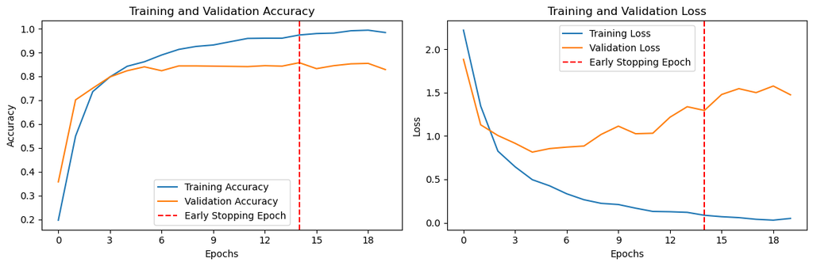

```python
from tensorflow.keras.optimizers import SGD

#Definir optimizador SGD
optimizer = SGD(learning_rate=0.01, momentum=0.9)

# Initialize the model
model3 = models.Sequential()

# First hidden layer (convolution layer)
model3.add(layers.Conv2D(32, (3, 3), padding='same', activation='relu', input_shape=(28, 28, 3)))
model3.add(layers.MaxPooling2D((2, 2)))

# Second hidden layer (convolution layer)
model3.add(layers.Conv2D(64, (3, 3), padding='same', activation='relu'))
model3.add(layers.MaxPooling2D((2, 2)))

# Third hidden layer (convolution layer)
model3.add(layers.Conv2D(128, (3, 3), padding='same', activation='relu'))

# Convert feature maps into individual units
model3.add(layers.Flatten())

# Add fully connected layer
model3.add(layers.Dense(64, activation='relu'))

# Add output layer
model3.add(layers.Dense(10, activation='softmax'))

# Compile the model
model3.compile(optimizer=optimizer,
              loss='categorical_crossentropy',
              metrics=['accuracy'])

# Train the model
history3 = model3.fit(train_generator_train,
    epochs=30,
    validation_data=val_generator, callbacks=[early_stop])

# Plotting the training and validation accuracy
stopped_epoch = early_stop.stopped_epoch
best_epoch = stopped_epoch - early_stop.patience

plt.figure(figsize=(12, 4))

plt.subplot(1, 2, 1)
plt.plot(history3.history['accuracy'], label='Training Accuracy')
plt.plot(history3.history['val_accuracy'], label='Validation Accuracy')
plt.axvline(x=best_epoch, color='r', linestyle='--', label='Early Stopping Epoch')
plt.title('Training and Validation Accuracy')
plt.xlabel('Epochs')
plt.ylabel('Accuracy')
plt.gca().xaxis.set_major_locator(MaxNLocator(integer=True))  # Ensure integer values on x-axis
plt.legend()

plt.subplot(1, 2, 2)
plt.plot(history3.history['loss'], label='Training Loss')
plt.plot(history3.history['val_loss'], label='Validation Loss')
plt.axvline(x=best_epoch, color='r', linestyle='--', label='Early Stopping Epoch')
plt.title('Training and Validation Loss')
plt.xlabel('Epochs')
plt.ylabel('Loss')
plt.gca().xaxis.set_major_locator(MaxNLocator(integer=True))  # Ensure integer values on x-axis
plt.legend()

plt.tight_layout()
plt.show()
```

Las gráficas nos muestran que el modelo tuvo su mejor momento alrededor de la época 14, donde podemos observar que el accuracy de Train estuvo alrededor de 0.96, y el accuracy de Test estuvo alrededor de 0.84, esta diferencia nos dice que el modelo tiene un ligero sobreajuste, pero para estar más seguros de su desempeño lo evaluaremos después con el dataset de 'Train' para darnos una idea de si es mejor o peor que el modelo base, comparando sus valores de accuracy entre ellos y entre las variaciones siguientes.

### **Variación 4**

Para la cuarta variación haremos uso de una técnica comunmente utilizada para aumentar la diversidad de datos dentro del dataset de entrenamiento, es decir, data augmentation, esto con la finalidad de mejorar la generalización del modelo.

```
Found 4168 images belonging to 10 classes.
131/131 ━━━━━━━━━━━━━━━━━━━━ 63s 475ms/step - accuracy: 0.5237 - loss: 1.6417 - val_accuracy: 0.8266 - val_loss: 0.8026
131/131 ━━━━━━━━━━━━━━━━━━━━ 59s 454ms/step - accuracy: 0.6669 - loss: 1.0791 - val_accuracy: 0.8430 - val_loss: 0.7527
131/131 ━━━━━━━━━━━━━━━━━━━━ 60s 460ms/step - accuracy: 0.6976 - loss: 0.9193 - val_accuracy: 0.8160 - val_loss: 0.8923
131/131 ━━━━━━━━━━━━━━━━━━━━ 60s 456ms/step - accuracy: 0.7364 - loss: 0.8429 - val_accuracy: 0.8516 - val_loss: 0.7677
131/131 ━━━━━━━━━━━━━━━━━━━━ 59s 454ms/step - accuracy: 0.7341 - loss: 0.8176 - val_accuracy: 0.8391 - val_loss: 0.7603
131/131 ━━━━━━━━━━━━━━━━━━━━ 120s 921ms/step - accuracy: 0.7648 - loss: 0.7106 - val_accuracy: 0.8545 - val_loss: 0.8257
131/131 ━━━━━━━━━━━━━━━━━━━━ 83s 634ms/step - accuracy: 0.7896 - loss: 0.6584 - val_accuracy: 0.7803 - val_loss: 0.8381
131/131 ━━━━━━━━━━━━━━━━━━━━ 60s 455ms/step - accuracy: 0.7859 - loss: 0.6698 - val_accuracy: 0.8642 - val_loss: 0.7032
131/131 ━━━━━━━━━━━━━━━━━━━━ 60s 457ms/step - accuracy: 0.7933 - loss: 0.6472 - val_accuracy: 0.8208 - val_loss: 0.7900
131/131 ━━━━━━━━━━━━━━━━━━━━ 60s 459ms/step - accuracy: 0.7891 - loss: 0.6543 - val_accuracy: 0.8430 - val_loss: 0.7624
131/131 ━━━━━━━━━━━━━━━━━━━━ 474s 4s/step - accuracy: 0.8048 - loss: 0.6106 - val_accuracy: 0.8690 - val_loss: 0.7804
131/131 ━━━━━━━━━━━━━━━━━━━━ 63s 481ms/step - accuracy: 0.8200 - loss: 0.5735 - val_accuracy: 0.8497 - val_loss: 0.8024
131/131 ━━━━━━━━━━━━━━━━━━━━ 62s 476ms/step - accuracy: 0.8197 - loss: 0.5858 - val_accuracy: 0.8324 - val_loss: 0.8562
131/131 ━━━━━━━━━━━━━━━━━━━━ 63s 483ms/step - accuracy: 0.8193 - loss: 0.5733 - val_accuracy: 0.8545 - val_loss: 0.7476
131/131 ━━━━━━━━━━━━━━━━━━━━ 63s 483ms/step - accuracy: 0.8330 - loss: 0.5440 - val_accuracy: 0.8574 - val_loss: 0.8051
131/131 ━━━━━━━━━━━━━━━━━━━━ 63s 482ms/step - accuracy: 0.8284 - loss: 0.5425 - val_accuracy: 0.8603 - val_loss: 0.8327
131/131 ━━━━━━━━━━━━━━━━━━━━ 64s 492ms/step - accuracy: 0.8293 - loss: 0.5351 - val_accuracy: 0.8478 - val_loss: 0.7709
131/131 ━━━━━━━━━━━━━━━━━━━━ 64s 489ms/step - accuracy: 0.8336 - loss: 0.5193 - val_accuracy: 0.8487 - val_loss: 0.8735
131/131 ━━━━━━━━━━━━━━━━━━━━ 64s 490ms/step - accuracy: 0.8276 - loss: 0.5446 - val_accuracy: 0.8786 - val_loss: 0.7327
131/131 ━━━━━━━━━━━━━━━━━━━━ 63s 481ms/step - accuracy: 0.8329 - loss: 0.5279 - val_accuracy: 0.8728 - val_loss: 0.7842
131/131 ━━━━━━━━━━━━━━━━━━━━ 63s 484ms/step - accuracy: 0.8360 - loss: 0.4920 - val_accuracy: 0.8690 - val_loss: 0.7400
131/131 ━━━━━━━━━━━━━━━━━━━━ 64s 488ms/step - accuracy: 0.8458 - loss: 0.4662 - val_accuracy: 0.8719 - val_loss: 0.6927
131/131 ━━━━━━━━━━━━━━━━━━━━ 63s 478ms/step - accuracy: 0.8542 - loss: 0.4481 - val_accuracy: 0.8709 - val_loss: 0.7682
131/131 ━━━━━━━━━━━━━━━━━━━━ 62s 476ms/step - accuracy: 0.8415 - loss: 0.4945 - val_accuracy: 0.8796 - val_loss: 0.8207
131/131 ━━━━━━━━━━━━━━━━━━━━ 63s 477ms/step - accuracy: 0.8435 - loss: 0.5002 - val_accuracy: 0.8622 - val_loss: 0.7939
131/131 ━━━━━━━━━━━━━━━━━━━━ 63s 484ms/step - accuracy: 0.8488 - loss: 0.4820 - val_accuracy: 0.8786 - val_loss: 0.7358
131/131 ━━━━━━━━━━━━━━━━━━━━ 62s 476ms/step - accuracy: 0.8345 - loss: 0.4948 - val_accuracy: 0.8266 - val_loss: 0.8116
131/131 ━━━━━━━━━━━━━━━━━━━━ 64s 486ms/step - accuracy: 0.8603 - loss: 0.4306 - val_accuracy: 0.8757 - val_loss: 0.7826
131/131 ━━━━━━━━━━━━━━━━━━━━ 63s 480ms/step - accuracy: 0.8570 - loss: 0.4318 - val_accuracy: 0.8805 - val_loss: 0.8363
131/131 ━━━━━━━━━━━━━━━━━━━━ 66s 504ms/step - accuracy: 0.8566 - loss: 0.4413 - val_accuracy: 0.8699 - val_loss: 0.8303
```

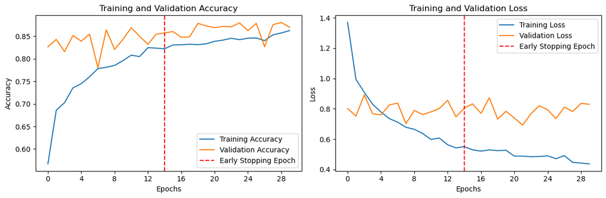

```python
#Código hecho con ayuda de ChatGPT
from tensorflow.keras.preprocessing.image import ImageDataGenerator

train_datagen = ImageDataGenerator(
    rescale=1./255,
    rotation_range=20,
    zoom_range=0.2,
    width_shift_range=0.2,
    height_shift_range=0.2,
    validation_split=0.2  # 20% del entrenamiento para validación
)

# Solo reescalado para validación
val_datagen = ImageDataGenerator(
    rescale=1./255,
    validation_split=0.2
)

# Entrenamiento con data augmentation
train_generator_aug = train_datagen.flow_from_directory(
    'Numbers/Train',
    target_size=(28, 28),
    color_mode='rgb',
    batch_size=32,
    class_mode='categorical',
    subset='training',
    shuffle=True
)

# Mantener modelo base
model4 = model1

# Train the model
history4 = model4.fit(
    train_generator_aug,
    epochs=30,
    validation_data=val_generator)

# Plotting the training and validation accuracy
stopped_epoch = early_stop.stopped_epoch
best_epoch = stopped_epoch - early_stop.patience

plt.figure(figsize=(12, 4))

plt.subplot(1, 2, 1)
plt.plot(history4.history['accuracy'], label='Training Accuracy')
plt.plot(history4.history['val_accuracy'], label='Validation Accuracy')
plt.axvline(x=best_epoch, color='r', linestyle='--', label='Early Stopping Epoch')
plt.title('Training and Validation Accuracy')
plt.xlabel('Epochs')
plt.ylabel('Accuracy')
plt.gca().xaxis.set_major_locator(MaxNLocator(integer=True))  # Ensure integer values on x-axis
plt.legend()

plt.subplot(1, 2, 2)
plt.plot(history4.history['loss'], label='Training Loss')
plt.plot(history4.history['val_loss'], label='Validation Loss')
plt.axvline(x=best_epoch, color='r', linestyle='--', label='Early Stopping Epoch')
plt.title('Training and Validation Loss')
plt.xlabel('Epochs')
plt.ylabel('Loss')
plt.gca().xaxis.set_major_locator(MaxNLocator(integer=True))  # Ensure integer values on x-axis
plt.legend()

plt.tight_layout()
plt.show()
```

### **Variación 5**

Para la quinta variación reduciremos los parámetros con la finalidad de hacer el modelo más eficiente. Utilizaremos menos capas, es decir, en lugar de tres capas, solo dos, y también disminuiremos las unidades en la capa Dense. Todo esto partiendo del primer modelo que creamos.

```
131/131 ━━━━━━━━━━━━━━━━━━━━ 67s 493ms/step - accuracy: 0.0937 - loss: 2.3577 - val_accuracy: 0.1012 - val_loss: 2.3026
131/131 ━━━━━━━━━━━━━━━━━━━━ 62s 475ms/step - accuracy: 0.1061 - loss: 2.3025 - val_accuracy: 0.1012 - val_loss: 2.3026
131/131 ━━━━━━━━━━━━━━━━━━━━ 60s 458ms/step - accuracy: 0.1061 - loss: 2.3026 - val_accuracy: 0.1012 - val_loss: 2.3026
131/131 ━━━━━━━━━━━━━━━━━━━━ 60s 454ms/step - accuracy: 0.1015 - loss: 2.3026 - val_accuracy: 0.1002 - val_loss: 2.3026
131/131 ━━━━━━━━━━━━━━━━━━━━ 59s 446ms/step - accuracy: 0.1024 - loss: 2.3025 - val_accuracy: 0.1012 - val_loss: 2.3026
131/131 ━━━━━━━━━━━━━━━━━━━━ 62s 472ms/step - accuracy: 0.0980 - loss: 2.3027 - val_accuracy: 0.1002 - val_loss: 2.3026
```

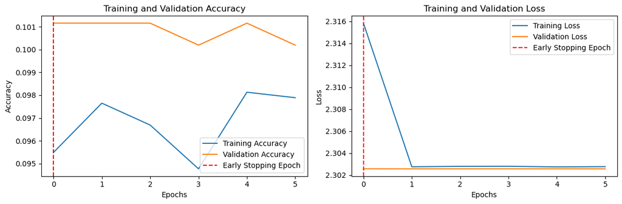

```python
# Initialize the model
model5 = models.Sequential()

# First hidden layer (convolution layer)
model5.add(layers.Conv2D(32, (3, 3), padding='same', input_shape=(28, 28, 3)))
model5.add(layers.BatchNormalization())
model5.add(layers.Activation('relu'))
model5.add(layers.MaxPooling2D((2, 2)))

# Second hidden layer (convolution layer)
model5.add(layers.Conv2D(64, (3, 3), padding='same', activation='relu'))
model5.add(layers.MaxPooling2D((2, 2)))

# Convert feature maps into individual units
model5.add(layers.Flatten())

# Add fully connected layer
model5.add(layers.Dense(32, activation='relu'))
model5.add(layers.Dropout(0.5))

# Add output layer
model5.add(layers.Dense(10, activation='softmax')) # 10 classes for digits 0-9

# Compile the model
model5.compile(optimizer='adam',
              loss='categorical_crossentropy',
              metrics=['accuracy'])

# Train the model
history5 = model5.fit(train_generator_train,
    epochs=30,
    validation_data=val_generator, callbacks=[early_stop])

# Plotting the training and validation accuracy
stopped_epoch = early_stop.stopped_epoch
best_epoch = stopped_epoch - early_stop.patience

plt.figure(figsize=(12, 4))

plt.subplot(1, 2, 1)
plt.plot(history5.history['accuracy'], label='Training Accuracy')
plt.plot(history5.history['val_accuracy'], label='Validation Accuracy')
plt.axvline(x=best_epoch, color='r', linestyle='--', label='Early Stopping Epoch')
plt.title('Training and Validation Accuracy')
plt.xlabel('Epochs')
plt.ylabel('Accuracy')
plt.gca().xaxis.set_major_locator(MaxNLocator(integer=True))  # Ensure integer values on x-axis
plt.legend()

plt.subplot(1, 2, 2)
plt.plot(history5.history['loss'], label='Training Loss')
plt.plot(history5.history['val_loss'], label='Validation Loss')
plt.axvline(x=best_epoch, color='r', linestyle='--', label='Early Stopping Epoch')
plt.title('Training and Validation Loss')
plt.xlabel('Epochs')
plt.ylabel('Loss')
plt.gca().xaxis.set_major_locator(MaxNLocator(integer=True))  # Ensure integer values on x-axis
plt.legend()

plt.tight_layout()
plt.show()
```

Las gráficas de este último modelo nos muestran lo pésimo que es. Es probable que la construcción de este modelo fuera demasiado simple para entender las imagenes dentro de Train, o tal vez hizo falta más paciencia o un learning rate distinto para mejorar su rendimiento, pero, de todos, es la peor de las variaciones.

### **Evaluación de modelos**

```python
# Evaluate the models
test_loss1, test_acc1 = model1.evaluate(test_generator)
test_loss2, test_acc2 = model2.evaluate(test_generator)
test_loss3, test_acc3 = model3.evaluate(test_generator)
test_loss4, test_acc4 = model4.evaluate(test_generator)
test_loss5, test_acc5 = model5.evaluate(test_generator)

print(f"Test accuracy Base: {test_acc}, Test loss Base: {test_loss}")
print(f"Test accuracy 1: {test_acc1}, Test loss 1: {test_loss1}")
print(f"Test accuracy 2: {test_acc2}, Test loss 2: {test_loss2}")
print(f"Test accuracy 3: {test_acc3}, Test loss 3: {test_loss3}")
print(f"Test accuracy 4: {test_acc4}, Test loss 4: {test_loss4}")
print(f"Test accuracy 5: {test_acc5}, Test loss 5: {test_loss5}")
```

```
44/44 ━━━━━━━━━━━━━━━━━━━━ 34s 787ms/step - accuracy: 0.8830 - loss: 0.3855
44/44 ━━━━━━━━━━━━━━━━━━━━ 18s 418ms/step - accuracy: 0.8454 - loss: 0.4803
44/44 ━━━━━━━━━━━━━━━━━━━━ 17s 401ms/step - accuracy: 0.8716 - loss: 0.7025
44/44 ━━━━━━━━━━━━━━━━━━━━ 18s 410ms/step - accuracy: 0.8830 - loss: 0.3855
44/44 ━━━━━━━━━━━━━━━━━━━━ 18s 405ms/step - accuracy: 0.1956 - loss: 2.3015
Test accuracy Base: 0.8482462167739868, Test loss Base: 0.8111635446548462
Test accuracy 1: 0.8775948286056519, Test loss 1: 0.3718659281730652
Test accuracy 2: 0.8582677245140076, Test loss 2: 0.4584704041481018
Test accuracy 3: 0.8732999563217163, Test loss 3: 0.6592133045196533
Test accuracy 4: 0.8775948286056519, Test loss 4: 0.3718659281730652
Test accuracy 5: 0.10236220806837082, Test loss 5: 2.3025903701782227
```

Como podemos observar, el modelo 1 y el modelo 4 son los que mejor trabajo hicieron durante la evaluación, pero, en general, todas las variaciones que se realizaron probaron ser mejores que el modelo base, exceptuando la útlima variación que buscaba resultados más simples y que consumieran menos recursos.

### **Modelo completo**

```
163/163 ━━━━━━━━━━━━━━━━━━━━ 197s 1s/step - accuracy: 0.3326 - loss: 1.9080 - val_accuracy: 0.5526 - val_loss: 1.7577
163/163 ━━━━━━━━━━━━━━━━━━━━ 99s 610ms/step - accuracy: 0.7454 - loss: 0.8348 - val_accuracy: 0.7717 - val_loss: 0.8763
163/163 ━━━━━━━━━━━━━━━━━━━━ 99s 611ms/step - accuracy: 0.8073 - loss: 0.5820 - val_accuracy: 0.8024 - val_loss: 0.6198
163/163 ━━━━━━━━━━━━━━━━━━━━ 94s 570ms/step - accuracy: 0.8564 - loss: 0.4450 - val_accuracy: 0.8361 - val_loss: 0.5104
163/163 ━━━━━━━━━━━━━━━━━━━━ 95s 583ms/step - accuracy: 0.8896 - loss: 0.3441 - val_accuracy: 0.8733 - val_loss: 0.4150
163/163 ━━━━━━━━━━━━━━━━━━━━ 94s 579ms/step - accuracy: 0.9117 - loss: 0.2855 - val_accuracy: 0.8661 - val_loss: 0.4308
163/163 ━━━━━━━━━━━━━━━━━━━━ 94s 577ms/step - accuracy: 0.9192 - loss: 0.2330 - val_accuracy: 0.8783 - val_loss: 0.4079
163/163 ━━━━━━━━━━━━━━━━━━━━ 92s 561ms/step - accuracy: 0.9313 - loss: 0.2044 - val_accuracy: 0.8640 - val_loss: 0.4594
163/163 ━━━━━━━━━━━━━━━━━━━━ 95s 585ms/step - accuracy: 0.9297 - loss: 0.2031 - val_accuracy: 0.8754 - val_loss: 0.4203
163/163 ━━━━━━━━━━━━━━━━━━━━ 93s 574ms/step - accuracy: 0.9480 - loss: 0.1578 - val_accuracy: 0.8797 - val_loss: 0.3992
163/163 ━━━━━━━━━━━━━━━━━━━━ 102s 627ms/step - accuracy: 0.9648 - loss: 0.1134 - val_accuracy: 0.8769 - val_loss: 0.4017
163/163 ━━━━━━━━━━━━━━━━━━━━ 99s 608ms/step - accuracy: 0.9596 - loss: 0.1120 - val_accuracy: 0.8805 - val_loss: 0.4328
163/163 ━━━━━━━━━━━━━━━━━━━━ 99s 609ms/step - accuracy: 0.9582 - loss: 0.1240 - val_accuracy: 0.8876 - val_loss: 0.4059
163/163 ━━━━━━━━━━━━━━━━━━━━ 101s 621ms/step - accuracy: 0.9605 - loss: 0.1089 - val_accuracy: 0.8991 - val_loss: 0.3558
163/163 ━━━━━━━━━━━━━━━━━━━━ 102s 628ms/step - accuracy: 0.9728 - loss: 0.0811 - val_accuracy: 0.8869 - val_loss: 0.5046
163/163 ━━━━━━━━━━━━━━━━━━━━ 104s 638ms/step - accuracy: 0.9680 - loss: 0.0968 - val_accuracy: 0.8719 - val_loss: 0.4576
163/163 ━━━━━━━━━━━━━━━━━━━━ 88s 544ms/step - accuracy: 0.9633 - loss: 0.0985 - val_accuracy: 0.8840 - val_loss: 0.4029
163/163 ━━━━━━━━━━━━━━━━━━━━ 79s 489ms/step - accuracy: 0.9662 - loss: 0.0991 - val_accuracy: 0.8862 - val_loss: 0.4378
163/163 ━━━━━━━━━━━━━━━━━━━━ 80s 489ms/step - accuracy: 0.9712 - loss: 0.0845 - val_accuracy: 0.8282 - val_loss: 0.5860
```

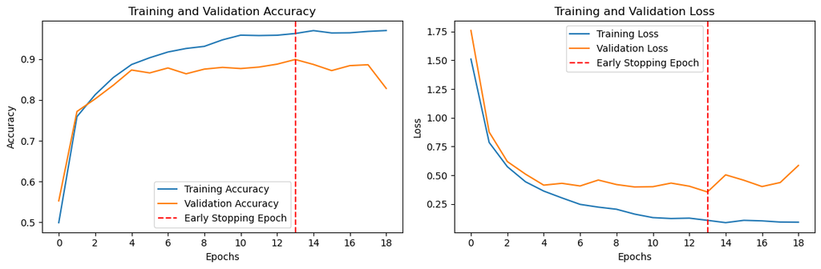

```python
# Initialize the model
model1 = models.Sequential()

# First hidden layer (convolution layer)
model1.add(layers.Conv2D(32, (3, 3), padding='same', input_shape=(28, 28, 3)))
model1.add(layers.BatchNormalization())
model1.add(layers.Activation('relu'))
model1.add(layers.MaxPooling2D((2, 2)))
model1.add(layers.Dropout(0.1))

# Second hidden layer (convolution layer)
model1.add(layers.Conv2D(64, (3, 3), padding='same', activation='relu'))
model1.add(layers.MaxPooling2D((2, 2)))
model1.add(layers.Dropout(0.1))

#Código con ayuda de ChatGPT
# Tercera hidden layer (convolution layer)
model1.add(layers.Conv2D(64, (3, 3), padding='same', activation='relu'))

# Cuarta hidden layer (convolution layer)
model1.add(layers.Conv2D(128, (3, 3), padding='same', activation='relu'))

# Convert feature maps into individual units
model1.add(layers.Flatten())

# Add fully connected layer
model1.add(layers.Dense(128, activation='relu'))
model1.add(layers.Dropout(0.25))

# Add output layer
model1.add(layers.Dense(10, activation='softmax')) # 10 classes for digits 0-9

# Compile the model
model1.compile(optimizer='adam',
              loss='categorical_crossentropy',
              metrics=['accuracy'])

# Train the model
history1 = model1.fit(train_generator,
    epochs=30,
    validation_data=test_generator, callbacks=[early_stop])

#history2 = model2.fit(train_images, train_labels, epochs=30, batch_size=64, validation_split=0.3, callbacks=[early_stop])

# Plotting the training and validation accuracy
stopped_epoch = early_stop.stopped_epoch
best_epoch = stopped_epoch - early_stop.patience

plt.figure(figsize=(12, 4))

plt.subplot(1, 2, 1)
plt.plot(history1.history['accuracy'], label='Training Accuracy')
plt.plot(history1.history['val_accuracy'], label='Validation Accuracy')
plt.axvline(x=best_epoch, color='r', linestyle='--', label='Early Stopping Epoch')
plt.title('Training and Validation Accuracy')
plt.xlabel('Epochs')
plt.ylabel('Accuracy')
plt.gca().xaxis.set_major_locator(MaxNLocator(integer=True))  # Ensure integer values on x-axis
plt.legend()

plt.subplot(1, 2, 2)
plt.plot(history1.history['loss'], label='Training Loss')
plt.plot(history1.history['val_loss'], label='Validation Loss')
plt.axvline(x=best_epoch, color='r', linestyle='--', label='Early Stopping Epoch')
plt.title('Training and Validation Loss')
plt.xlabel('Epochs')
plt.ylabel('Loss')
plt.gca().xaxis.set_major_locator(MaxNLocator(integer=True))  # Ensure integer values on x-axis
plt.legend()

plt.tight_layout()
plt.show()
```

```python
test_loss1, test_acc1 = model1.evaluate(test_generator)
print(f"Test accuracy FN: {test_acc1}, Test loss FN: {test_loss1}")
```

```
44/44 ━━━━━━━━━━━━━━━━━━━━ 19s 431ms/step - accuracy: 0.9070 - loss: 0.3419
Test accuracy FN: 0.8990694284439087, Test loss FN: 0.3558073341846466
```

Por las gráficas podemos observar que el accuracy de Train para este modelo final está alrededor del 0.95 y el accuracy de Test es de alrededor 0.88. Esto nos da un buen modelo que es capz de identificar numeros del 0 al 9 con bastante confianza y sin sobreajuste alarmante.

### **Matriz de Confusión**

```
44/44 ━━━━━━━━━━━━━━━━━━━━ 19s 429ms/step
```

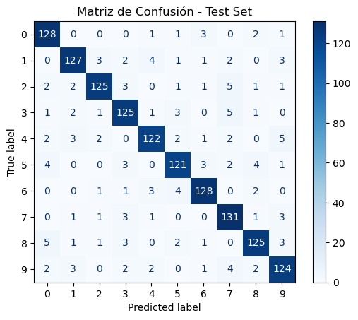

```python
#Código hecho con ayuda de ChatGPT
from sklearn.metrics import confusion_matrix, ConfusionMatrixDisplay
import seaborn as sns

# Predicciones del modelo
predictions = model1.predict(test_generator)
y_pred = np.argmax(predictions, axis=1)

# Etiquetas reales
y_true = test_generator.classes

# Matriz de confusión
cm = confusion_matrix(y_true, y_pred)
labels = list(test_generator.class_indices.keys())

# Visualización
disp = ConfusionMatrixDisplay(confusion_matrix=cm, display_labels=labels)
plt.figure(figsize=(8, 8))
disp.plot(cmap=plt.cm.Blues, values_format='d')
plt.title('Matriz de Confusión - Test Set')
plt.show()
```

Gracias al gráfico anterior podemos observar que el modelo no comete *tantos* errores. Parece que el número 5 y el número 4 son los que más conflicto le generan al modelo, pues el modelo confunde muchos de los '5' dentro de Test por otros números como '0' y '8', y además confunde muchos '4' con '1' y '9'. Pero, en general, parece que el modelo puede determinar el número que se le muestra con bastante consistencia.

```python
# Save the model
model1.save("my_model.h5")
```

```
WARNING:absl:You are saving your model as an HDF5 file via `model.save()` or `keras.saving.save_model(model)`. This file format is considered legacy. We recommend using instead the native Keras format, e.g. `model.save('my_model.keras')` or `keras.saving.save_model(model, 'my_model.keras')`.
```

```python
%%writefile real_time_prediction_CNN.py

import cv2
import numpy as np
import tensorflow as tf

# Cargar el modelo
model = tf.keras.models.load_model("my_model.h5")

cap = cv2.VideoCapture(0)

try:
    while True:
        ret, frame = cap.read()
        if not ret:
            break

        # Preprocesar la imagen (mantener en RGB)
        resized = cv2.resize(frame, (28, 28))
        normalized = resized / 255.0
        input_img = normalized.reshape(1, 28, 28, 3)

        # Predecir
        prediction = model.predict(input_img, verbose=0)
        predicted_label = np.argmax(prediction)
        prediction_probs = prediction.flatten()

        # Clonar frame para dibujo
        frame_with_prediction = frame.copy()

        # Mostrar todas las probabilidades
        for i, prob in enumerate(prediction_probs):
            text = f"{i}: {prob:.2f}"
            color = (0, 255, 0) if i == predicted_label else (0, 0, 255)
            y_position = 30 + i * 25
            cv2.putText(frame_with_prediction, text, (10, y_position),
                        cv2.FONT_HERSHEY_SIMPLEX, 0.7, color, 2, cv2.LINE_AA)

        # Mostrar el número predicho de forma grande
        cv2.putText(frame_with_prediction, f"Pred: {predicted_label}", (300, 30),
                    cv2.FONT_HERSHEY_SIMPLEX, 1.2, (255, 0, 0), 2, cv2.LINE_AA)

        # Mostrar ventanas
        cv2.imshow('Real-time prediction', frame_with_prediction)

        # Mostrar la imagen reescalada de entrada
        upscaled_resized = cv2.resize(normalized, (280, 280), interpolation=cv2.INTER_NEAREST)
        cv2.imshow('Resized Input (RGB)', upscaled_resized)

        # Salir con 'q'
        if cv2.waitKey(1) & 0xFF == ord('q'):
            break

except KeyboardInterrupt:
    pass
finally:
    cap.release()
    cv2.destroyAllWindows()
```

```
Writing real_time_prediction_CNN.py
```

### *Doy mi palabra de que he realizado esta actividad en integridad académica.*